# Traffic_Sign_Classifier

## Project: Build a Traffic Sign Recognition Classifier

## Step 0: Load The Data

```python
# Package Definitions
import pickle

import numpy as np

import cv2
import random
import matplotlib.pyplot as plt
import matplotlib.gridspec as gridspec
# Visualizations will be shown in the notebook.
%matplotlib inline

import pandas as pd
from sklearn.utils import shuffle
```

```python
# Load pickled data

training_file = 'train.p'
validation_file = 'valid.p'
testing_file = 'test.p'

with open(training_file, mode='rb') as f:
    train = pickle.load(f)
with open(validation_file, mode='rb') as f:
    valid = pickle.load(f)
with open(testing_file, mode='rb') as f:
    test = pickle.load(f)

X_train, y_train = train['features'], train['labels']
X_valid, y_valid = valid['features'], valid['labels']
X_test, y_test = test['features'], test['labels']
```

## Step 1: Dataset Summary & Exploration

### Basic Summary of the Data Set Using Python, Numpy and/or Pandas

```python
### Replace each question mark with the appropriate value.
### Use python, pandas or numpy methods rather than hard coding the results

# TODO: Number of training examples
n_train = len(X_train)

# TODO: Number of validation examples
n_validation = len(X_valid)

# TODO: Number of testing examples.
n_test = len(X_train)

# TODO: What's the shape of an traffic sign image?
image_shape = X_train[0].shape

# TODO: How many unique classes/labels there are in the dataset.
n_classes = len(np.unique(y_train))

print("Number of training examples =", n_train)
print("Number of validation examples =", n_validation)
print("Number of testing examples =", n_test)
print("Image data shape =", image_shape)
print("Number of classes =", n_classes)
```

```
Number of training examples = 34799
Number of validation examples = 4410
Number of testing examples = 34799
Image data shape = (32, 32, 3)
Number of classes = 43
```

### Exploratory visualization of the dataset

```python
### Data exploration visualization code goes here.
### Feel free to use as many code cells as needed.

def plot_images(row,col,X,y):

    fig, axs = plt.subplots(row,col, figsize=(12, 12))
    fig.subplots_adjust(hspace = .2, wspace=.001)
    axs = axs.ravel()

    for i in range(row*col):
        index = np.random.randint(0, len(X_train))
        image = X_train[index]

        axs[i].axis('off')
        axs[i].imshow(image)
        axs[i].set_title(y_train[index])
    plt.show()
```

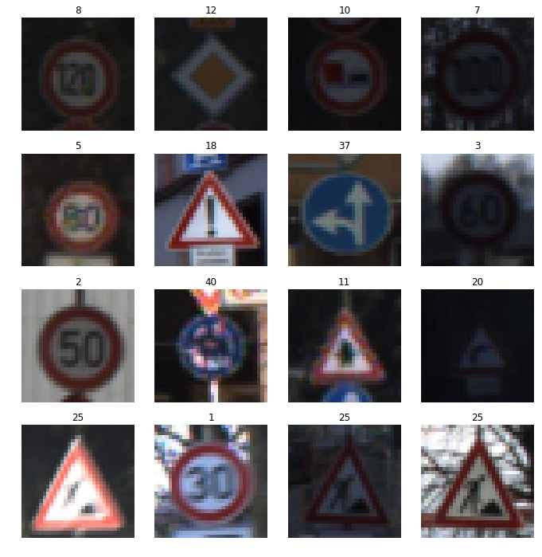

```python
plot_images(4,4,X_train,y_train)
```

## Step 2: Design and Test a Model Architecture

### Question 1

*Describe the techniques used to preprocess the data.*

#### Answer

I used two main pro-processing steps:

1. Normalizing the images so that they pixel values are between -0.5 and 0.5
2. Equalizing all the 3 channels so that the brightness effect is removed

```python
### Preprocess the data here. It is required to normalize the data. Other preprocessing steps could include
### converting to grayscale, etc.
### Feel free to use as many code cells as needed.

def normalize_image(image):
    image = image/255-0.5
    return image

def equalize_channels(image):
    image[:,:,0] = cv2.equalizeHist(image[:,:,0])
    image[:,:,1] = cv2.equalizeHist(image[:,:,1])
    image[:,:,2] = cv2.equalizeHist(image[:,:,2])
    return image

def grayscale_image(image):
    gray_image = cv2.cvtColor(image, cv2.COLOR_BGR2GRAY)
    return gray_image

def equalize_grayscale(image):
    image = cv2.equalizeHist(image)
    return image

def transform_image(image,angle,shear,trans):

    #rotation
    rotation_angle = np.random.uniform(angle)-angle/2
    rows,cols,ch = image.shape
    rotation_matrix = cv2.getRotationMatrix2D((cols/2,rows/2),rotation_angle,1)
    image = cv2.warpAffine(image,rotation_matrix,(cols,rows))

    # Translation
    deltaX = trans*np.random.uniform()-trans/2
    deltaY = trans*np.random.uniform()-trans/2
    trans_matrix = np.float32([[1,0,deltaX],[0,1,deltaY]])
    image = cv2.warpAffine(image,trans_matrix,(cols,rows))

    # Shear
    pts1 = np.float32([[10,10],[20,10],[10,20]])
    pt1 = 10+shear*np.random.uniform()-shear/2
    pt2 = 20+shear*np.random.uniform()-shear/2
    pts2 = np.float32([[pt1,10],[pt2,pt1],[10,pt2]])

    shear_matrix = cv2.getAffineTransform(pts1,pts2)

    image = cv2.warpAffine(image,shear_matrix,(cols,rows))

    return image

def generate_data(X_train,y_train,angle,shear,trans):
    n_train = len(y_train)

    X_new = []
    y_new = []
    for i in range(n_train):

        for j in range(5):
            trans_image = transform_image(X_train[i],angle,shear,trans)
            X_new.append(trans_image)
            y_new.append(y_train[i])

    X_new = np.array(X_new)
    y_new = np.array(y_new)

    return X_new, y_new

def show(image):
    plt.figure(figsize = (3,3))
    plt.imshow(image)

def plot_transformed(row,col,X,y):
    fig, axs = plt.subplots(row,col, figsize=(12, 12))
    fig.subplots_adjust(hspace = .2, wspace=.001)
    axs = axs.ravel()

    for i in range(0,row*col,2):
        index = np.random.randint(0, len(X_train))
        image = X_train[index]
        transformed_image = transform_image(image,20,5,5)

        axs[i].axis('off')
        axs[i].imshow(image)
        axs[i].set_title(y_train[index])

        axs[i+1].axis('off')
        axs[i+1].imshow(transformed_image)
        axs[i+1].set_title(y_train[index])
    plt.show()
```

### Question 2

*Describe how you set up the training, validation and testing data for your model. If you generated additional data, why?*

```python
trans_X,trans_y = generate_data(X_train,y_train,20,5,5)

processed_X_train = np.array([normalize_image(equalize_channels(trans_X[i]))
                       for i in range(len(trans_X))])
processed_X_valid = np.array([normalize_image(equalize_channels(X_valid[i]))
                       for i in range(len(X_valid))])
processed_X_test = np.array([normalize_image(equalize_channels(X_test[i]))
                       for i in range(len(X_test))])
processed_y_train = trans_y
processed_y_valid = y_valid
processed_y_test = y_test
```

```
(173995, 32, 32, 3) (173995,)
(173995, 32, 32, 3) (173995,)
```

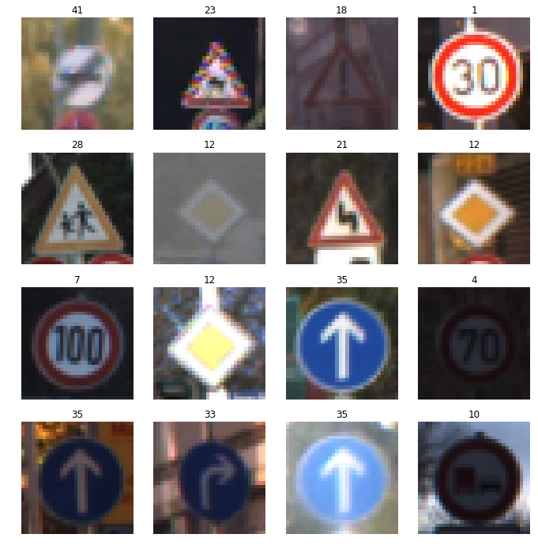

```python
print(processed_X_train.shape,processed_y_train.shape)
print(trans_X.shape,trans_y.shape)
plot_images(4,4,trans_X,trans_y)
```

```python
occurance_Class = [[i,sum(trans_y == i)] for i in range(len(np.unique(trans_y)))]
occurance_Class_sorted = sorted(occurance_Class, key=lambda x: x[1])
data_pd = pd.read_csv('signnames.csv')

data_pd['Occurance'] = pd.Series(np.asarray(occurance_Class_sorted).T[1], index=np.asarray(occurance_Class_sorted).T[0])
data_pd_sorted = data_pd.sort_values(['Occurance'],ascending=[0]).reset_index()
data_pd_sorted
```

|  | index | ClassId | SignName | Occurance |
| --- | --- | --- | --- | --- |
| 0 | 2 | 2 | Speed limit (50km/h) | 10050 |
| 1 | 1 | 1 | Speed limit (30km/h) | 9900 |
| 2 | 13 | 13 | Yield | 9600 |
| 3 | 12 | 12 | Priority road | 9450 |
| 4 | 38 | 38 | Keep right | 9300 |
| 5 | 10 | 10 | No passing for vehicles over 3.5 metric tons | 9000 |
| 6 | 4 | 4 | Speed limit (70km/h) | 8850 |
| 7 | 5 | 5 | Speed limit (80km/h) | 8250 |
| 8 | 25 | 25 | Road work | 6750 |
| 9 | 9 | 9 | No passing | 6600 |
| 10 | 7 | 7 | Speed limit (100km/h) | 6450 |
| 11 | 3 | 3 | Speed limit (60km/h) | 6300 |
| 12 | 8 | 8 | Speed limit (120km/h) | 6300 |
| 13 | 11 | 11 | Right-of-way at the next intersection | 5850 |
| 14 | 35 | 35 | Ahead only | 5400 |
| 15 | 18 | 18 | General caution | 5400 |
| 16 | 17 | 17 | No entry | 4950 |
| 17 | 31 | 31 | Wild animals crossing | 3450 |
| 18 | 14 | 14 | Stop | 3450 |
| 19 | 33 | 33 | Turn right ahead | 2995 |
| 20 | 15 | 15 | No vehicles | 2700 |
| 21 | 26 | 26 | Traffic signals | 2700 |
| 22 | 28 | 28 | Children crossing | 2400 |
| 23 | 23 | 23 | Slippery road | 2250 |
| 24 | 30 | 30 | Beware of ice/snow | 1950 |
| 25 | 16 | 16 | Vehicles over 3.5 metric tons prohibited | 1800 |
| 26 | 34 | 34 | Turn left ahead | 1800 |
| 27 | 6 | 6 | End of speed limit (80km/h) | 1800 |
| 28 | 36 | 36 | Go straight or right | 1650 |
| 29 | 22 | 22 | Bumpy road | 1650 |
| 30 | 40 | 40 | Roundabout mandatory | 1500 |
| 31 | 20 | 20 | Dangerous curve to the right | 1500 |
| 32 | 39 | 39 | Keep left | 1350 |
| 33 | 21 | 21 | Double curve | 1350 |
| 34 | 29 | 29 | Bicycles crossing | 1200 |
| 35 | 24 | 24 | Road narrows on the right | 1200 |
| 36 | 41 | 41 | End of no passing | 1050 |
| 37 | 42 | 42 | End of no passing by vehicles over 3.5 metric ... | 1050 |
| 38 | 32 | 32 | End of all speed and passing limits | 1050 |
| 39 | 27 | 27 | Pedestrians | 1050 |
| 40 | 37 | 37 | Go straight or left | 900 |
| 41 | 19 | 19 | Dangerous curve to the left | 900 |
| 42 | 0 | 0 | Speed limit (20km/h) | 900 |

```python
### Define your architecture here.
### Feel free to use as many code cells as needed.

import tensorflow as tf

EPOCHS = 20
BATCH_SIZE = 100
```

```python
x = tf.placeholder(tf.float32, (None, image_shape[0], image_shape[1], image_shape[2]), name='features')
y = tf.placeholder(tf.int32, (None), name='true_labels')
one_hot_y = tf.one_hot(y, n_classes)

keep_prob = tf.placeholder(tf.float32)
```

### Question 3

*What does your final architecture look like? (Type of model, layers, sizes, connectivity, etc.) For reference on how to build a deep neural network using TensorFlow, see Deep Neural Network in TensorFlow from the classroom.*

#### Answer:

The structure used is described below

##### Layer 1

- Convolution 1x1 filter output shape is same as input shape 32x32x3
- Convolution 5x5 filter with 16 outputs
- Convolution 5x5 filter with 32 outputs
- 2x2 max pooling

The output of the last layer is flattened for connection to a fully connected layer. It is possible to have many different architectures and add complexity through inception modules and so on. But here I just chose this architecture once the validation accuracy exceeded 98%.

The two fully connected layers have 50% drop outs layer after each to prevent over fitting. This is finally connectd to the output layer with 43 outputs for the 43 classes.

The test accuracy reached was 96.8%.

```python
from tensorflow.contrib.layers import flatten

def LeNet(x,keep_prob):

    # Arguments used for tf.truncated_normal, randomly defines variables for the weights and biases for each layer
    mu = 0
    sigma = 0.1

    conv_strides = [1, 1, 1, 1]
    pool_strides = [1, 2, 2, 1]

    weights = {
        'wc0': tf.Variable(tf.truncated_normal(shape=(1, 1, 3, 3), mean = mu, stddev = sigma)),
        'wc1': tf.Variable(tf.truncated_normal(shape=(5, 5, 3, 16), mean = mu, stddev = sigma)),
        'wc2': tf.Variable(tf.truncated_normal(shape=(5, 5, 16, 32), mean = mu, stddev = sigma)),
        'wc3': tf.Variable(tf.truncated_normal(shape=(1, 1, 32, 32), mean = mu, stddev = sigma)),
        'wc4': tf.Variable(tf.truncated_normal(shape=(5, 5, 32, 64), mean = mu, stddev = sigma)),
        'wc5': tf.Variable(tf.truncated_normal(shape=(5, 5, 64, 128), mean = mu, stddev = sigma)),
        'wc6': tf.Variable(tf.truncated_normal(shape=(1, 1, 128, 128), mean = mu, stddev = sigma)),
        'wc7': tf.Variable(tf.truncated_normal(shape=(5, 5, 128, 256), mean = mu, stddev = sigma)),
        'wc8': tf.Variable(tf.truncated_normal(shape=(5, 5, 256, 256), mean = mu, stddev = sigma)),
        'wd1': tf.Variable(tf.truncated_normal(shape=(4096, 1024), mean = mu, stddev = sigma)),
        'wd2': tf.Variable(tf.truncated_normal(shape=(1024, 256), mean = mu, stddev = sigma)),
        'out': tf.Variable(tf.truncated_normal(shape=(256, n_classes), mean = mu, stddev = sigma))}

    biases = {
        'bc0': tf.Variable(tf.zeros(3)),
        'bc1': tf.Variable(tf.zeros(16)),
        'bc2': tf.Variable(tf.zeros(32)),
        'bc3': tf.Variable(tf.zeros(32)),
        'bc4': tf.Variable(tf.zeros(64)),
        'bc5': tf.Variable(tf.zeros(128)),
        'bc6': tf.Variable(tf.zeros(128)),
        'bc7': tf.Variable(tf.zeros(256)),
        'bc8': tf.Variable(tf.zeros(256)),
        'bd1': tf.Variable(tf.zeros(1024)),
        'bd2': tf.Variable(tf.zeros(256)),
        'out': tf.Variable(tf.zeros(n_classes))}

    # Layer 0: input 32, 32, 3 output 32, 32, 3
    conv0 = tf.nn.conv2d(x, weights['wc0'], strides=conv_strides, padding='SAME')
    conv0 = tf.nn.bias_add(conv0, biases['bc0'])
    conv0 = tf.nn.relu(conv0)
    print('Conv0',conv0.get_shape())

    # Layer 1: Convolutional. Input = . Output =
    conv1 = tf.nn.conv2d(conv0, weights['wc1'], strides=conv_strides, padding='SAME')
    conv1 = tf.nn.bias_add(conv1, biases['bc1'])
    conv1 = tf.nn.relu(conv1)
    print('Conv1',conv1.get_shape())

    # Layer 2: Convolutional. Input = . Output =
    conv2 = tf.nn.conv2d(conv1, weights['wc2'], strides=conv_strides, padding='SAME')
    conv2 = tf.nn.bias_add(conv2, biases['bc2'])
    conv2 = tf.nn.relu(conv2)
    print('Conv2',conv2.get_shape())

    # Pooling
    conv2 = tf.nn.max_pool(conv2, ksize=[1, 2, 2, 1], strides=pool_strides, padding='SAME')
    print('Pool Conv2',conv2.get_shape())

    # Layer 3: Convolutional. Input = . Output =
    conv3 = tf.nn.conv2d(conv2, weights['wc3'], strides=conv_strides, padding='SAME')
    conv3 = tf.nn.bias_add(conv3, biases['bc3'])
    conv3 = tf.nn.relu(conv3)
    print('Conv2',conv3.get_shape())

    # Layer 4: Convolutional. Input = . Output =
    conv4 = tf.nn.conv2d(conv3, weights['wc4'], strides=conv_strides, padding='SAME')
    conv4 = tf.nn.bias_add(conv4, biases['bc4'])
    conv4 = tf.nn.relu(conv4)
    print('Conv4',conv4.get_shape())

    # Layer 5: Convolutional. Input = . Output =
    conv5 = tf.nn.conv2d(conv4, weights['wc5'], strides=conv_strides, padding='SAME')
    conv5 = tf.nn.bias_add(conv5, biases['bc5'])
    conv5 = tf.nn.relu(conv5)
    print('Conv5',conv5.get_shape())

    # Pooling
    conv5 = tf.nn.max_pool(conv5, ksize=[1, 2, 2, 1], strides=pool_strides, padding='SAME')
    print('Pool Conv5',conv5.get_shape())

    # Layer 6: Convolutional. Input = . Output =
    conv6 = tf.nn.conv2d(conv5, weights['wc6'], strides=conv_strides, padding='SAME')
    conv6 = tf.nn.bias_add(conv6, biases['bc6'])
    conv6 = tf.nn.relu(conv6)
    print('Conv6',conv6.get_shape())

    # Layer 7: Convolutional. Input = . Output =
    conv7 = tf.nn.conv2d(conv6, weights['wc7'], strides=conv_strides, padding='SAME')
    conv7 = tf.nn.bias_add(conv7, biases['bc7'])
    conv7 = tf.nn.relu(conv7)
    print('Conv7',conv7.get_shape())

    # Layer 8: Convolutional. Input = . Output =
    conv8 = tf.nn.conv2d(conv7, weights['wc8'], strides=conv_strides, padding='SAME')
    conv8 = tf.nn.bias_add(conv8, biases['bc8'])
    conv8 = tf.nn.relu(conv8)
    print('Conv8',conv8.get_shape())

    # Pooling
    conv8 = tf.nn.max_pool(conv8, ksize=[1, 2, 2, 1], strides=pool_strides, padding='SAME')
    print('Pool Conv8',conv8.get_shape())

    # concatenate layers after dropping
    flatten_conv2 = flatten(conv2)
    flatten_conv5 = flatten(conv5)
    flatten_conv8 = flatten(conv8)
    print('Flat8', flatten_conv8.get_shape())

    # Layer Fully Connected. Using only the last flat layer
    fc1 = tf.add(tf.matmul(flatten_conv8, weights['wd1']),biases['bd1'])
    fc1 = tf.nn.relu(fc1)
    fc1 = tf.nn.dropout(fc1, keep_prob)
    print('fc1',fc1.get_shape())

    # Layer Fully Connected.
    fc2 = tf.add(tf.matmul(fc1, weights['wd2']),biases['bd2'])
    fc2 = tf.nn.relu(fc2)
    fc2 = tf.nn.dropout(fc2, keep_prob)
    print('fc2',fc2.get_shape())

    # Layer Fully Connected.
    logits = tf.add(tf.matmul(fc2, weights['out']),biases['out'])
    print('logits',logits.get_shape())

    labels_pred = tf.nn.softmax(logits)

    regularizer = (tf.nn.l2_loss(weights['wc0'])
                    + tf.nn.l2_loss(weights['wc1']) + tf.nn.l2_loss(weights['wc2'])
                    + tf.nn.l2_loss(weights['wc3']) + tf.nn.l2_loss(weights['wc4'])
                    + tf.nn.l2_loss(weights['wc5']) + tf.nn.l2_loss(weights['wc6'])
                    + tf.nn.l2_loss(weights['wc7']) + tf.nn.l2_loss(weights['wc8'])
                    + tf.nn.l2_loss(weights['wd1']) + tf.nn.l2_loss(weights['wd2'])
                    + tf.nn.l2_loss(weights['out']))

    return logits, regularizer, labels_pred
```

```python
rate = 0.001

logits, regulizer, labels_pred = LeNet(x, keep_prob)
cross_entropy = tf.nn.softmax_cross_entropy_with_logits(labels=one_hot_y, logits=logits)
loss_operation = tf.reduce_mean(cross_entropy)+1e-6*regulizer
optimizer = tf.train.AdamOptimizer(learning_rate = rate)
training_operation = optimizer.minimize(loss_operation)

correct_prediction = tf.equal(tf.argmax(logits, 1), tf.argmax(one_hot_y, 1))
accuracy_operation = tf.reduce_mean(tf.cast(correct_prediction, tf.float32))
saver = tf.train.Saver()

def evaluate(X_data, y_data):
    num_examples = len(X_data)
    total_accuracy = 0
    sess = tf.get_default_session()
    for offset in range(0, num_examples, BATCH_SIZE):
        batch_x, batch_y = X_data[offset:offset+BATCH_SIZE], y_data[offset:offset+BATCH_SIZE]
        accuracy = sess.run(accuracy_operation, feed_dict={x: batch_x, y: batch_y, keep_prob: 1.0})
        total_accuracy += (accuracy * len(batch_x))
    return total_accuracy / num_examples
```

```
Conv0 (?, 32, 32, 3)
Conv1 (?, 32, 32, 16)
Conv2 (?, 32, 32, 32)
Pool Conv2 (?, 16, 16, 32)
Conv2 (?, 16, 16, 32)
Conv4 (?, 16, 16, 64)
Conv5 (?, 16, 16, 128)
Pool Conv5 (?, 8, 8, 128)
Conv6 (?, 8, 8, 128)
Conv7 (?, 8, 8, 256)
Conv8 (?, 8, 8, 256)
Pool Conv8 (?, 4, 4, 256)
Flat8 (?, 4096)
fc1 (?, 1024)
fc2 (?, 256)
logits (?, 43)
```

### Train, Validate and Test the Model

### Question 4

*How did you train your model? (Type of optimizer, batch size, epochs, hyperparameters, etc.)*

```python
### Train your model here.
### Calculate and report the accuracy on the training and validation set.
### Once a final model architecture is selected,
### the accuracy on the test set should be calculated and reported as well.
### Feel free to use as many code cells as needed.

with tf.Session() as sess:
    sess.run(tf.global_variables_initializer())
    num_examples = len(processed_X_train)

    print("Training...")
    print()
    for i in range(EPOCHS):
        pro_X_train, pro_y_train = shuffle(processed_X_train, processed_y_train)
        for offset in range(0, num_examples, BATCH_SIZE):
            end = offset + BATCH_SIZE
            batch_x, batch_y = pro_X_train[offset:end], pro_y_train[offset:end]
            sess.run(training_operation, feed_dict={x: batch_x, y: batch_y, keep_prob: 0.5})

        validation_accuracy = evaluate(processed_X_valid, processed_y_valid)
        print("EPOCH {} ...".format(i+1))
        print("Validation Accuracy = {:.3f}".format(validation_accuracy))
        print()

        saver.save(sess, './my_tsnet.ckpt')

    print("Model saved")
```

```
Training...

EPOCH 1 ...
Validation Accuracy = 0.938

EPOCH 2 ...
Validation Accuracy = 0.976

EPOCH 3 ...
Validation Accuracy = 0.970

EPOCH 4 ...
Validation Accuracy = 0.992

EPOCH 5 ...
Validation Accuracy = 0.955

EPOCH 6 ...
Validation Accuracy = 0.983

EPOCH 7 ...
Validation Accuracy = 0.986

EPOCH 8 ...
Validation Accuracy = 0.987

EPOCH 9 ...
Validation Accuracy = 0.984

EPOCH 10 ...
Validation Accuracy = 0.985

EPOCH 11 ...
Validation Accuracy = 0.994

EPOCH 12 ...
Validation Accuracy = 0.988

EPOCH 13 ...
Validation Accuracy = 0.988
```

[output cut: 8 more lines]

```
Validation Accuracy = 0.984

EPOCH 17 ...
Validation Accuracy = 0.994

EPOCH 18 ...
Validation Accuracy = 0.989

EPOCH 19 ...
Validation Accuracy = 0.990

EPOCH 20 ...
Validation Accuracy = 0.985

Model saved
```

```python
with tf.Session() as sess:
    saver.restore(sess, './my_tsnet.ckpt')

    test_accuracy = evaluate(processed_X_test, processed_y_test)
    print("Test Accuracy = {:.3f}".format(test_accuracy))
```

[output not shown]

### Question 5

Solution approach?

#### Answer

I started with the Lenet architecture with gave me 80% validation accuracy at the outset without any modification to the images. Preprocessing the images improved the accuracy to about 92%. After this I started tweaking the hyper parameters to see if I can gain any improvement. This was the most inefficient part of the process - essetially tuning some parameters to gain some improvement in performance. Soon I abondoned this and started focusing on the network architecture. Literature suggested having 3 layers to identify features from basic shapes like lines to more advanced features. The lectures also suggested using 1x1 filter convolutions to increase depth without incurring computational penalties. This was used to come up with the architecture described above.

There are a lot of knobs to turn here to gain small improvements here and there, but once I got the validation accuracy above 98% I stopped fiddling with the structure and the hyper parameters.

## Step 3: Test a Model on New Images

### Load and Output the Images

```
(87, 84, 3)
```

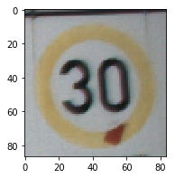

```python
### Load the images and plot them here.
### Feel free to use as many code cells as needed.

from scipy.misc import imread
img = imread('./test_images/01.ppm')
print(img.shape)
show(img)
```

```python
def read_images(filename):
    img = cv2.imread(filename)
    img = cv2.resize(img,(32,32))
    return img

def transform_german_images(filename):
    img = cv2.imread(filename)
    img = cv2.resize(img,(32,32))

    img[:,:,0] = cv2.equalizeHist(img[:,:,0])
    img[:,:,2] = cv2.equalizeHist(img[:,:,2])
    img[:,:,1] = cv2.equalizeHist(img[:,:,1])
    img = img/255.-.5

    return img

def plot_german_images(row,col,X):

    fig, axs = plt.subplots(row,col, figsize=(12, 12))
    fig.subplots_adjust(hspace = .2, wspace=.001)
    axs = axs.ravel()

    for i in range(row*col):
        index = np.random.randint(0, len(X))
        image = X[index]

        axs[i].axis('off')
        axs[i].imshow(image)
    plt.show()
```

```python
import os

german_images =  [read_images("./test_images/"+name) for name in os.listdir("./test_images/")]
new_images = [transform_german_images("./test_images/"+name) for name in os.listdir("./test_images/")]
new_labels = np.array([name for name in os.listdir("./test_images/")])
new_images = np.array(new_images,dtype = np.float32)

lab = []
for label in new_labels:
    lab.append(int(label[:2]))

print(lab)
```

```
[21, 35, 32, 18, 25, 4, 20, 10, 9, 31, 38, 11, 2, 7, 42, 8, 26, 29, 12, 23, 19, 34, 37, 28, 5, 40, 15, 3, 36, 6, 17, 22, 14, 13, 39, 27, 41, 30, 33, 0, 16, 24, 1]
```

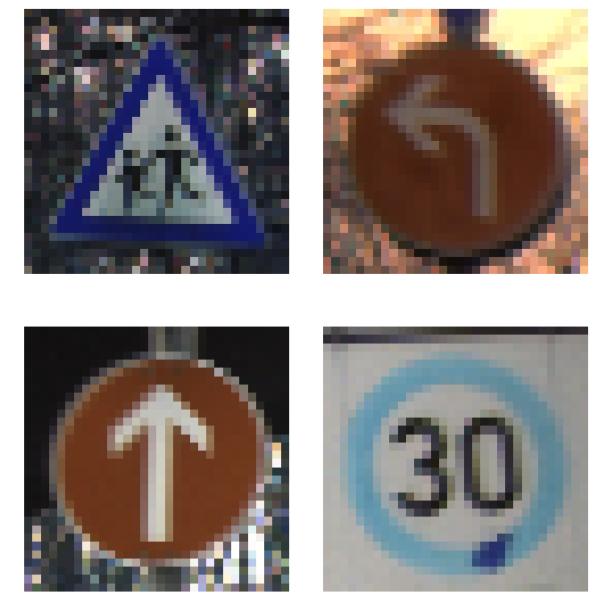

```python
plot_german_images(2,2,german_images)
```

```python
signnames = data_pd['SignName']
```

### Predict the Sign Type for Each Image

### Question 6

Choose five candidate images of traffic signs and provide them in the report. Are there any particular qualities of the image(s) that might make classification difficult?

#### Answer:

Random images were downloaded from the German data set. The netwrok will perform well on images which it has obviously seen before, however, images which are completely new will most likely be misclassified. It is also possible that color might confuse the network. For example in the US data set, Stop sign has a large area with red color. If a sign with large red area is observed, in absence of strong distinguishing features, it might be misclassified.

### Analyze Performance

The performance on the new images is compared to the accuracy results of the test set is poor 79% vs 96.8%.

79% is also a pretty high value. I wuld have expected it to be even lower. It is possible that the images I chose were coincedentally similar to US data set. The network has most trouble with the speed limit signs and signs with large red areas.

### Top 5 softmax probabilities

```
INFO:tensorflow:Restoring parameters from ./my_tsnet.ckpt
Accuracy on German Images = 0.791
```

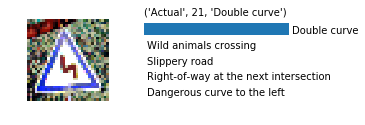

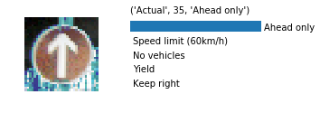

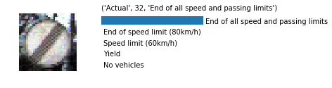

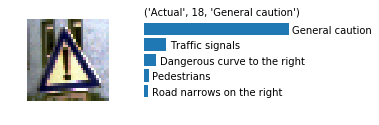

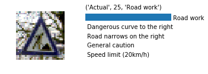

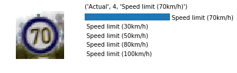

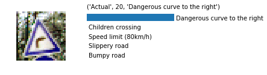

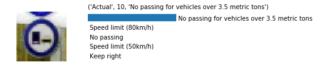

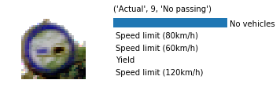

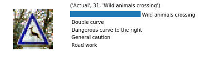

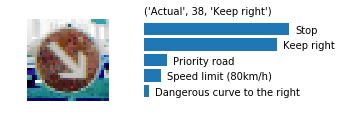

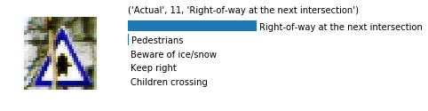

[31 more figures not shown]

```python
### Run the predictions here and use the model to output the prediction for each image.
### Make sure to pre-process the images with the same pre-processing pipeline used earlier.
### Feel free to use as many code cells as needed.

#labels_pred = tf.nn.softmax(fc_layer3)
with tf.Session() as sess:
    sess.run(tf.global_variables_initializer())
    saver.restore(sess, './my_tsnet.ckpt')

    german_accuracy = evaluate(new_images, lab)
    print("Accuracy on German Images = {:.3f}".format(german_accuracy))

    feed_dict_new = {x :new_images, y :lab, keep_prob: 1}
    top5 = tf.nn.top_k(labels_pred, 5)

    predictions = sess.run(labels_pred,feed_dict = feed_dict_new)
    top5_pred = sess.run([labels_pred, top5], feed_dict=feed_dict_new)

    for i in range(43):
        plt.figure(figsize = (5,1.5))
        gs = gridspec.GridSpec(1, 2,width_ratios=[2,3])
        plt.subplot(gs[0])
        plt.imshow(new_images[i]+.5)
        plt.axis('off')
        plt.subplot(gs[1])
        plt.barh(6-np.arange(5),top5_pred[1][0][i], align='center')
        for i_label in range(5):
            plt.text(top5_pred[1][0][i][i_label]+.02,6-i_label-.25,
                data_pd['SignName'][top5_pred[1][1][i][i_label]])
        plt.axis('off');
        plt.text(0,6.95,('Actual',lab[i],signnames[lab[i]]));
        plt.show();
```